# Covid Examples

# In-class exercise

```r
### Load the libraries will we need
library(readr)
library(dplyr)
library(ggplot2)
```

Read the data and check

```r
gapminder <- read_csv("raw_data/gapminder.csv")
head(gapminder)
```

| country | continent | year | lifeExp | pop | gdpPercap |
| --- | --- | --- | --- | --- | --- |
| Afghanistan | Asia | 1952 | 28.801 | 8425333 | 779.4453 |
| Afghanistan | Asia | 1957 | 30.332 | 9240934 | 820.8530 |
| Afghanistan | Asia | 1962 | 31.997 | 10267083 | 853.1007 |
| Afghanistan | Asia | 1967 | 34.020 | 11537966 | 836.1971 |
| Afghanistan | Asia | 1972 | 36.088 | 13079460 | 739.9811 |
| Afghanistan | Asia | 1977 | 38.438 | 14880372 | 786.1134 |

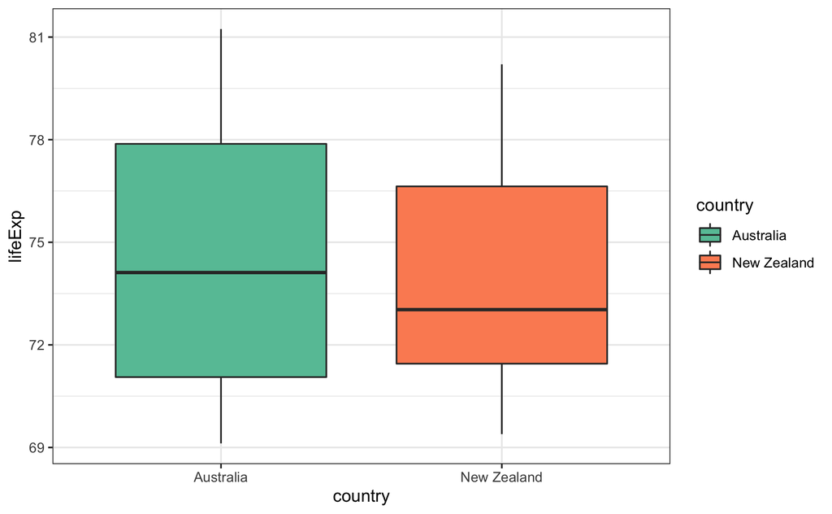

```r
library(RColorBrewer)
gapminder %>%
  filter(continent == "Oceania") %>%
  ggplot(aes(x = country, y = lifeExp,fill=country)) + geom_boxplot() + scale_fill_manual(values=brewer.pal(2,"Set2")) + theme_bw()
```

Summarise the gapminder data in an appropriate manner to produce a plot to show the change in average gdpPercap for each continent over time.

```r
## advisable to do the summary first and check the result

group_by(gapminder, continent, year) %>%
  summarise(GDP = mean(gdpPercap))
```

| continent | year | GDP |
| --- | --- | --- |
| Africa | 1952 | 1252.572 |
| Africa | 1957 | 1385.236 |
| Africa | 1962 | 1598.079 |
| Africa | 1967 | 2050.364 |
| Africa | 1972 | 2339.616 |
| Africa | 1977 | 2585.939 |
| Africa | 1982 | 2481.593 |
| Africa | 1987 | 2282.669 |
| Africa | 1992 | 2281.810 |
| Africa | 1997 | 2378.760 |

[output cut: 50 more lines]

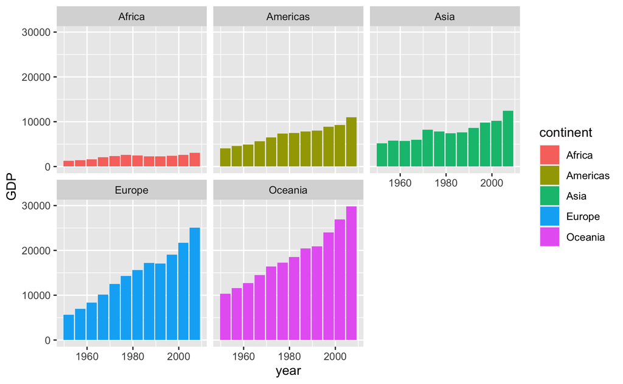

```r
group_by(gapminder, continent, year) %>%
  summarise(GDP = mean(gdpPercap)) %>%
  ggplot(aes(x = year, y = GDP, fill=continent)) + geom_col() + facet_wrap(~continent)
```

# Some examples of visualising the Covid-19 dataset using `dplyr` and `ggplot2`

First load the required libraries

```r
library(readr)
library(dplyr)
library(ggplot2)
library(tidyr)
```

Download the Covid dataset and tidy

```r
download.file("https://raw.githubusercontent.com/CSSEGISandData/COVID-19/master/csse_covid_19_data/csse_covid_19_time_series/time_series_covid19_confirmed_global.csv",destfile = "raw_data/time_series_covid19_confirmed_global.csv")
covid <- read_csv("raw_data/time_series_covid19_confirmed_global.csv") %>%
  rename(country = `Country/Region`) %>%
  pivot_longer(5:last_col(),names_to="Date", values_to="Cases") %>%
  mutate(Date=as.Date(Date,"%m/%d/%y")) %>%
  group_by(country,Date) %>%
  summarise(Cases = sum(Cases))
```

Compare trajectories of different countries. The `%in%` operator is an alternative to or (`|`) to find a country name that can either one of a number of possibilities.

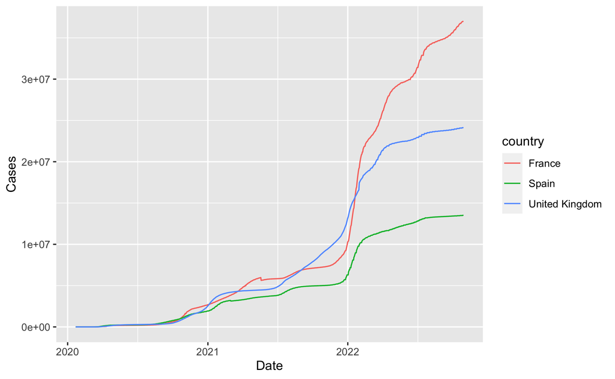

```r
filter(covid, country %in% c("United Kingdom","France","Spain")) %>%
  ggplot(aes(x = Date, y = Cases,col=country)) + geom_line()
```

Try to make example similar to https://www.statista.com/statistics/1110187/coronavirus-incidence-europe-by-country/. We’re not using up-to-date figures for population so there will be some differences. The two data frames can be joined because they have a column name in common (`country`). Most of the country names that appear in `gapminder` also appear in the `covid` dataset, so not much data is lost in the join.

Since we are interested in European countries for this dataset, we pre-filter the `gapminder` data. Also, we only need the population values from 2007.

```r
##change the date to whichever date you want to look at

filter(gapminder, year == 2007,continent=="Europe") %>%
  left_join(covid) %>%
  filter(Date == "2022-01-06") %>%
  mutate(Cases = round(Cases / (pop / 1e5)))
```

| country | continent | year | lifeExp | pop | gdpPercap | Date | Cases |
| --- | --- | --- | --- | --- | --- | --- | --- |
| Albania | Europe | 2007 | 76.423 | 3600523 | 5937.030 | 2022-01-06 | 5923 |
| Austria | Europe | 2007 | 79.829 | 8199783 | 36126.493 | 2022-01-06 | 15865 |
| Belgium | Europe | 2007 | 79.441 | 10392226 | 33692.605 | 2022-01-06 | 21237 |
| Bosnia and Herzegovina | Europe | 2007 | 74.852 | 4552198 | 7446.299 | 2022-01-06 | 6532 |
| Bulgaria | Europe | 2007 | 73.005 | 7322858 | 10680.793 | 2022-01-06 | 10515 |
| Croatia | Europe | 2007 | 75.748 | 4493312 | 14619.223 | 2022-01-06 | 16592 |
| Denmark | Europe | 2007 | 78.332 | 5468120 | 35278.419 | 2022-01-06 | 17001 |
| Finland | Europe | 2007 | 79.313 | 5238460 | 33207.084 | 2022-01-06 | 6031 |
| France | Europe | 2007 | 80.657 | 61083916 | 30470.017 | 2022-01-06 | 18483 |
| Germany | Europe | 2007 | 79.406 | 82400996 | 32170.374 | 2022-01-06 | 8934 |

[output cut: 18 more lines]

We can use a `geom_col` plot to visualise

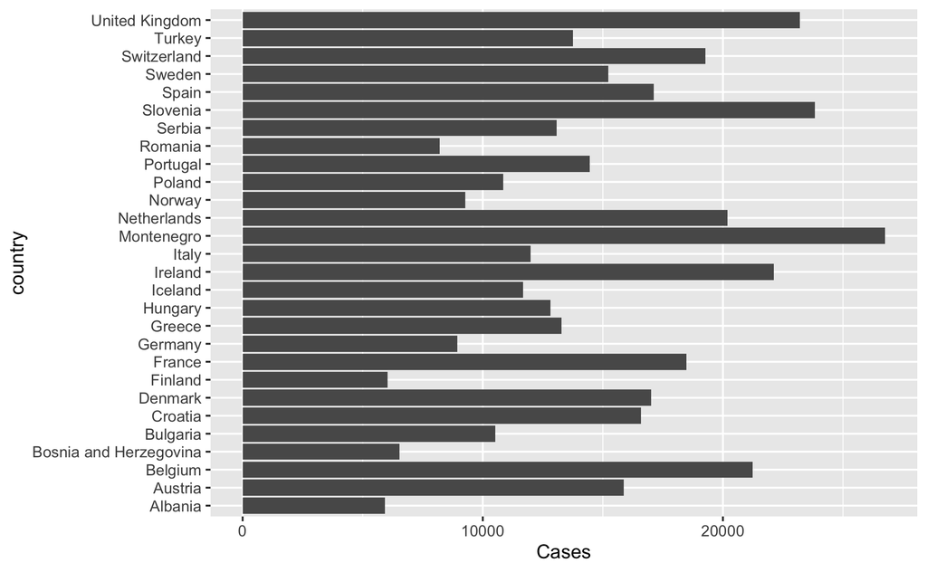

```r
filter(gapminder, year == 2007,continent=="Europe") %>%
  left_join(covid) %>%
  filter(Date == "2022-01-06") %>%
  mutate(Cases = round(Cases / (pop / 1e5))) %>%
  ggplot(aes(x = Cases, y = country)) + geom_col()
```

The default ordering for the bars is alphabetical, which is probably not a natural choice. The `forcats` package, which is part of `tidyverse` allows *factors* in a data frame to be re-ordered and re-labeled.

- [forcats package](https://forcats.tidyverse.org/)

In particular, we can use the `fct_reorder` function to reorder the country names according to the number of cases. This can be done inside the `ggplot2` function itself.

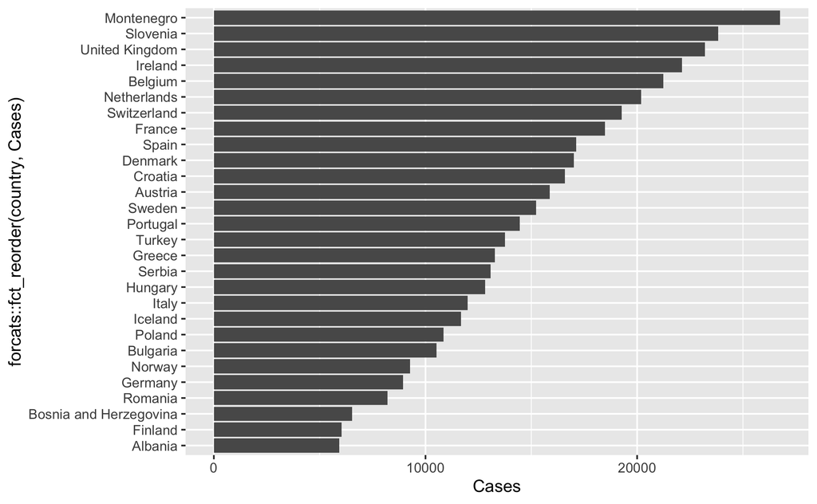

```r
## this will install the package if it is not already installed
if(!require(forcats)) install.packages(forcats)

filter(gapminder, year == 2007,continent=="Europe") %>%
  left_join(covid) %>%
  filter(Date == "2022-01-06") %>%
  mutate(Cases = round(Cases / (pop / 1e5))) %>%
  ggplot(aes(x = Cases, y = forcats::fct_reorder(country,Cases))) + geom_col()
```

A heatmap of number of cases over time (similar to that reported by the BBC) can be achieved using a `geom_tile`

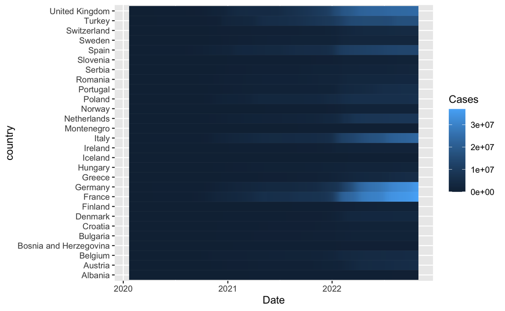

```r
### Get the 2007 gapminder data to avoid repeating data
filter(gapminder, year ==  2007, continent=="Europe") %>%
  left_join(covid) %>%
  filter(!is.na(Cases)) %>% ## remove countries with missing values
  ggplot(aes(x = Date, y = country,fill=Cases)) + geom_tile()
```

```r
NA
```

```r
## find out the last data in the covid dataset

latest_date <- pull(covid,Date) %>% max

filter(gapminder, year == 2007) %>%
  select(country, continent) %>%   right_join(covid) %>%
filter(Date == latest_date) %>%
  group_by(continent) %>%
  arrange(desc(Cases)) %>%
  slice(1)
##slice(1) returns the first row
```

[output not shown]